# A2_KohWindsor

2024-03-10

## Introduction

This notebook was created by *Koh Zhi Cong Windsor* using his own made Docker image from Homework Assignment 1. Relevant packages are installed. The dataset’s accession number is GSE228090, and was downloaded from GEO. The gene counts (which are normalised and filtered), as well as the sample information are loaded from Assignment 1’s operations.

## Differential Gene Expression

There are other factors that affect the gene expression. There are two cell lines, and for each cell line treatment, there are up to 3 replicates, labelled S1 to S3.

In addition, two different MEKi and ERKi are used each (but only one control).

### MDS

I plot multiple MDS plots to demonstrate my choice of factors in my model. From these plots, the cell line appears to be a major factor that will influence results.

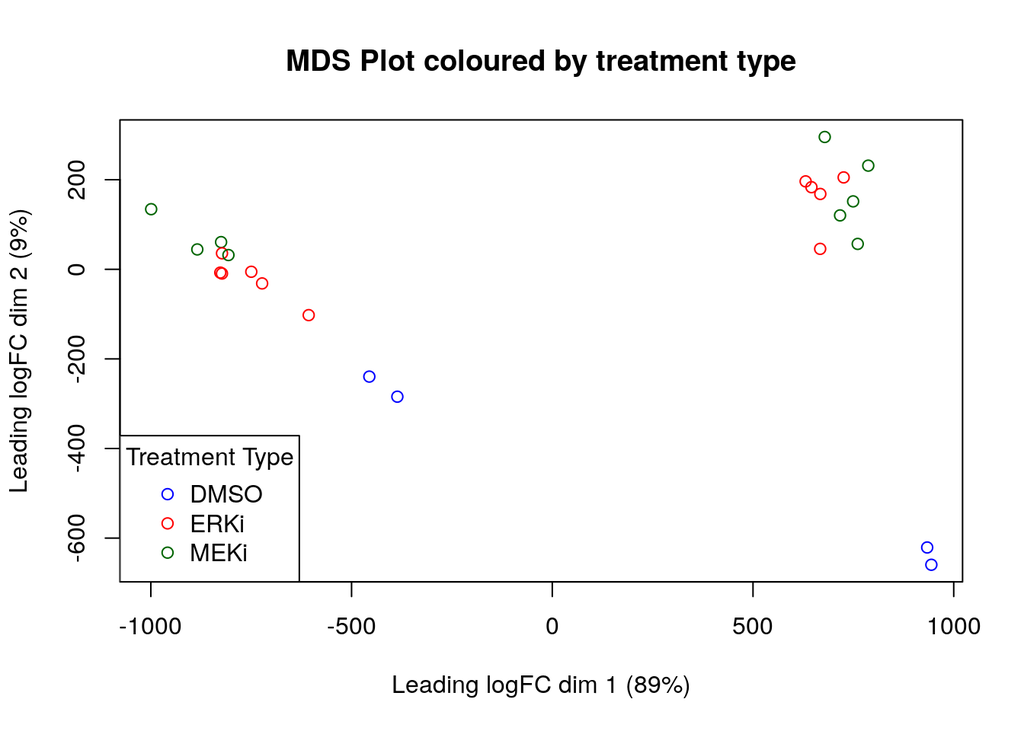

**Figure 1:** MDS plot of normalised counts, coloured by treatment type

```r
# Create MDS plot by treatment type
plotMDS(normalised_counts, labels=NULL, pch = 1, col = c("blue", "red","darkgreen")[factor(sample_info$treatment.type)])
title(main = "MDS Plot coloured by treatment type")
legend("bottomleft", legend = levels(factor(sample_info$treatment.type)),
       col = c("blue", "red", "darkgreen"), pch = 1, title = "Treatment Type")
```

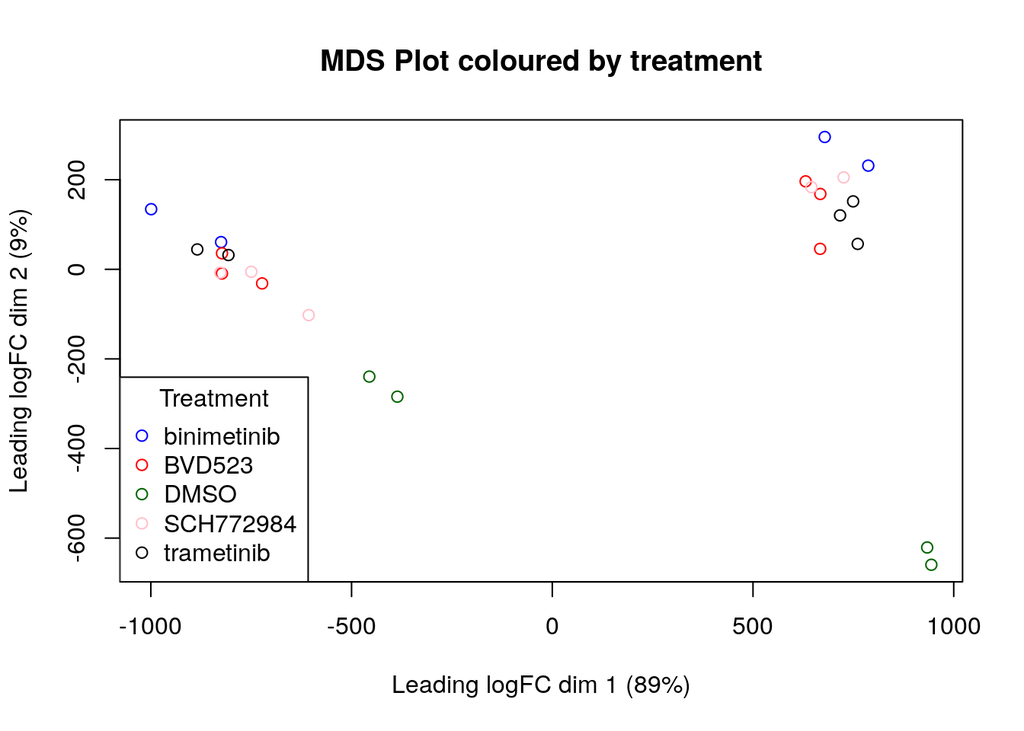

**Figure 2:** MDS plot of normalised counts, coloured by treatment

```r
# Create MDS plot by treatment
plotMDS(normalised_counts, labels=NULL, pch = 1, col = c("blue", "red","darkgreen","pink","black")[factor(sample_info$treatment)])
title(main = "MDS Plot coloured by treatment")
legend("bottomleft", legend = levels(factor(sample_info$treatment)),
       col = c("blue", "red","darkgreen","pink","black"), pch = 1, title = "Treatment")
```

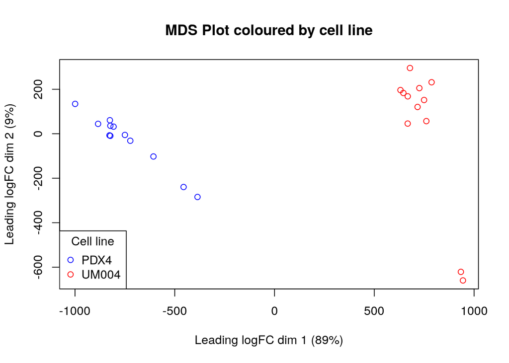

**Figure 3:** MDS plot of normalised counts, coloured by cell line

```r
# Create MDS plot by cell line
plotMDS(normalised_counts, labels=NULL, pch = 1, col = c("blue", "red")[factor(sample_info$cell.line)])
title(main = "MDS Plot coloured by cell line")
legend("bottomleft", legend = levels(factor(sample_info$cell.line)),
       col = c("blue", "red"), pch = 1, title = "Cell line")
```

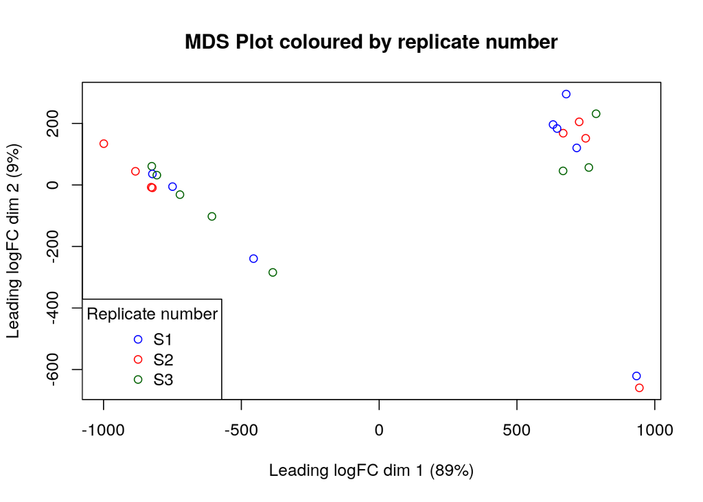

**Figure 4:** MDS plot of normalised counts, coloured by replicate number

```r
# Create MDS plot by cell line
plotMDS(normalised_counts, labels=NULL, pch = 1, col = c("blue", "red", "darkgreen")[factor(sample_info$sample.number)])
title(main = "MDS Plot coloured by replicate number")
legend("bottomleft", legend = levels(factor(sample_info$sample.number)),
       col = c("blue", "red", "darkgreen"), pch = 1, title = "Replicate number")
```

Since there are three treatment types, I first create two different counts tables, one excluding MEKi (for ERKi vs DMSO comparison), and one excluding ERKi (for MEKi vs DMSO comparison). This will facilitate the linear model fitting subsequently.

```r
ERKi_and_DMSO <- sample_info[sample_info$treatment.type == "ERKi" | sample_info$treatment.type == "DMSO",]
normalised_counts_ERKi <- normalised_counts[,rownames(ERKi_and_DMSO)]

MEKi_and_DMSO <- sample_info[sample_info$treatment.type == "MEKi" | sample_info$treatment.type == "DMSO",]
normalised_counts_MEKi <- normalised_counts[,rownames(MEKi_and_DMSO)]
```

### Model design

The model would utilise cell line as well as the treatment type. In other words, the effect of treatment type is corrected for by the differences between the cell lines.

```r
model_design_ERKi <- model.matrix(~ ERKi_and_DMSO$cell.line + ERKi_and_DMSO$treatment.type)
model_design_MEKi <- model.matrix(~ MEKi_and_DMSO$cell.line + MEKi_and_DMSO$treatment.type)
```

### Model fitting

EdgeR is used to fit the counts into the model earlier to produce different fits; one for ERKi and one for MEKi.

```r
d1 = DGEList(counts=normalised_counts_ERKi, group=ERKi_and_DMSO$treatment.type)
d1 <- estimateDisp(d1, model_design_ERKi)
fit_ERKi <- glmQLFit(d1, model_design_ERKi)

d2 = DGEList(counts=normalised_counts_MEKi, group=MEKi_and_DMSO$treatment.type)
d2 <- estimateDisp(d2, model_design_MEKi)
fit_MEKi <- glmQLFit(d2, model_design_MEKi)
```

The Quasilikelihood model is used to calculate the genes’ differential expression. Since I am comparing the addition of ERKi or MEKi, with reference to the control (DMSO), I then make two separate calculations, one for MEKi and one for ERKi. I note that the top few differentially expressed genes are different for MEKi and for ERKi.

```r
qlf.treatment_typeERKi <- glmQLFTest(fit_ERKi, coef="ERKi_and_DMSO$treatment.typeERKi")
knitr::kable(topTags(qlf.treatment_typeERKi),type='html',row.names=TRUE)
```

[output not shown]

|  | x |
| --- | --- |
| 1 | BH |

|  | x |
| --- | --- |
| 1 | ERKi_and_DMSO$treatment.typeERKi |

|  | x |
| --- | --- |
| 1 | glm |

```r
qlf.treatment_typeMEKi <- glmQLFTest(fit_MEKi, coef="MEKi_and_DMSO$treatment.typeMEKi")
knitr::kable(topTags(qlf.treatment_typeMEKi),type='html',row.names=TRUE)
```

|  | logFC | logCPM | F | PValue | FDR |
| --- | --- | --- | --- | --- | --- |
| ETV4 | -5.916666 | 3.765001 | 1740.8369 | 0 | 0 |
| ALDH1A3 | -2.329185 | 4.498330 | 1465.2401 | 0 | 0 |
| CPN1 | -4.723206 | 3.438473 | 1201.2821 | 0 | 0 |
| MAG | -2.662552 | 3.857434 | 1141.1319 | 0 | 0 |
| ALDH1A3-AS1 | -2.319119 | 3.899520 | 1011.7188 | 0 | 0 |
| STATH | -3.562229 | 2.725909 | 800.7989 | 0 | 0 |
| DLX1 | -2.636110 | 3.923678 | 730.3745 | 0 | 0 |
| HKDC1 | -3.049761 | 3.439030 | 719.2614 | 0 | 0 |
| MCM2 | -2.099401 | 5.074141 | 705.5784 | 0 | 0 |
| BCAN | 2.490487 | 9.981043 | 686.2840 | 0 | 0 |

|  | x |
| --- | --- |
| 1 | BH |

|  | x |
| --- | --- |
| 1 | MEKi_and_DMSO$treatment.typeMEKi |

|  | x |
| --- | --- |
| 1 | glm |

### Multiple hypothesis testing

Using the threshold of p-value < 0.05, we can find the number of genes that pass the threshold. About a third of the genes are differentially expressed when either MEKi or ERKi are added. By default, using edgeR uses the BH correction method, and thus used for correction. The number of genes passing correction are shown too.

```r
qlf_output_hits_ERKi <- topTags(qlf.treatment_typeERKi, sort.by = "PValue", n = nrow(normalised_counts_ERKi))
dim(qlf_output_hits_ERKi$table) # there are a total of 14693 genes
```

```
## [1] 14693     5
```

```r
length(which(qlf_output_hits_ERKi$table$PValue < 0.05)) # number of genes that pass threshold of p-value < 0.05
```

```
## [1] 5725
```

```r
length(which(qlf_output_hits_ERKi$table$FDR < 0.05)) # number of genes that pass correction
```

```
## [1] 4622
```

```r
FDR<-p.adjust(qlf_output_hits_ERKi$table$PValue,method="BH")
sum(FDR<0.05) # these are the same number of genes as above. This shows FDR is calculated using the BH method.
```

```
## [1] 4622
```

```r
## Same process for MEKi
qlf_output_hits_MEKi <- topTags(qlf.treatment_typeMEKi, sort.by = "PValue", n = nrow(normalised_counts_MEKi))
length(which(qlf_output_hits_MEKi$table$PValue < 0.05)) # number of genes that pass threshold of p-value < 0.05
```

```
## [1] 6145
```

```r
length(which(qlf_output_hits_MEKi$table$FDR < 0.05)) # number of genes that pass correction
```

```
## [1] 5093
```

### MA Plot

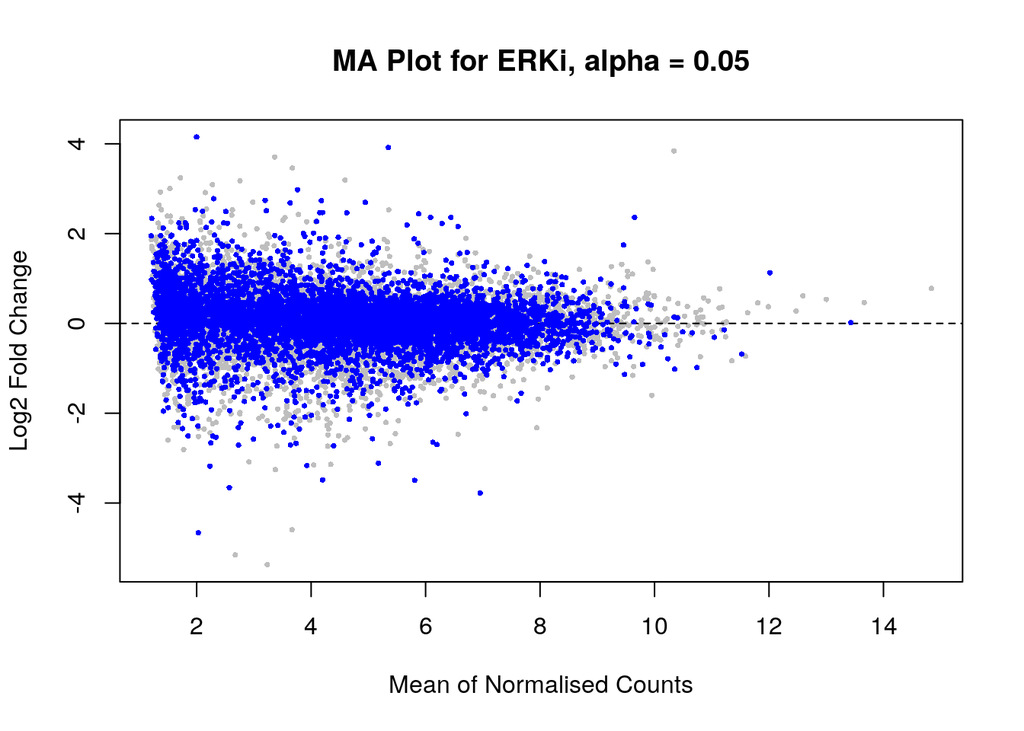

```r
# Calculate log-fold change and average expression level based on fit

# Create MA plot
plot(qlf.treatment_typeERKi$table$logCPM, qlf.treatment_typeERKi$table$logFC, pch = 16, col = "grey", cex = 0.5,
     xlab = "Mean of Normalised Counts", ylab = "Log2 Fold Change",
     main = "MA Plot for ERKi, alpha = 0.05")

# Add a horizontal line at log-fold change = 0 (no change)
abline(h = 0, col = "black", lty = 2)

# blue points have p < 0.05
points(qlf.treatment_typeERKi$table$logCPM[ qlf_output_hits_ERKi$table$PValue < 0.05],
       qlf.treatment_typeERKi$table$logFC[qlf_output_hits_ERKi$table$PValue < 0.05],
       pch = 16, col = "blue", cex = 0.5)
```

The process is repeated for MEKi.

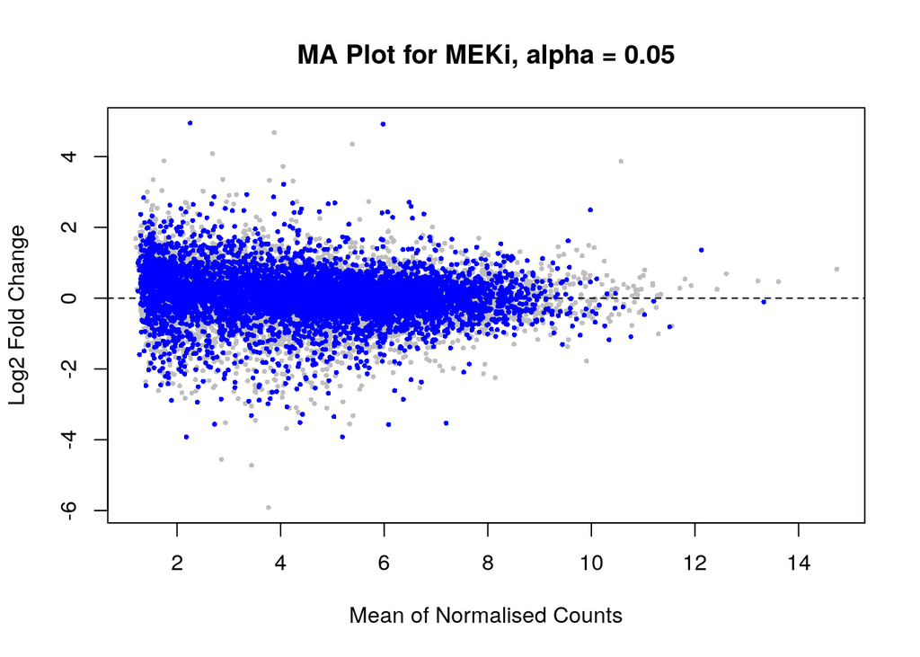

```r
# Create MA plot
plot(qlf.treatment_typeMEKi$table$logCPM, qlf.treatment_typeMEKi$table$logFC, pch = 16, col = "grey", cex = 0.5,
     xlab = "Mean of Normalised Counts", ylab = "Log2 Fold Change",
     main = "MA Plot for MEKi, alpha = 0.05")

# Add a horizontal line at log-fold change = 0 (no change)
abline(h = 0, col = "black", lty = 2)

# blue points have p < 0.05
points(qlf.treatment_typeMEKi$table$logCPM[qlf_output_hits_MEKi$table$PValue < 0.05],
       qlf.treatment_typeMEKi$table$logFC[qlf_output_hits_MEKi$table$PValue < 0.05],
       pch = 16, col = "blue", cex = 0.5)
```

### Heatmap

To find which genes clusters are due to the difference in treatment types, I first find the top hits, which are those genes that are differentially expressed with p value < 0.05 for ERKi vs control (DMSO). These are visualised in an annotated heatmap.

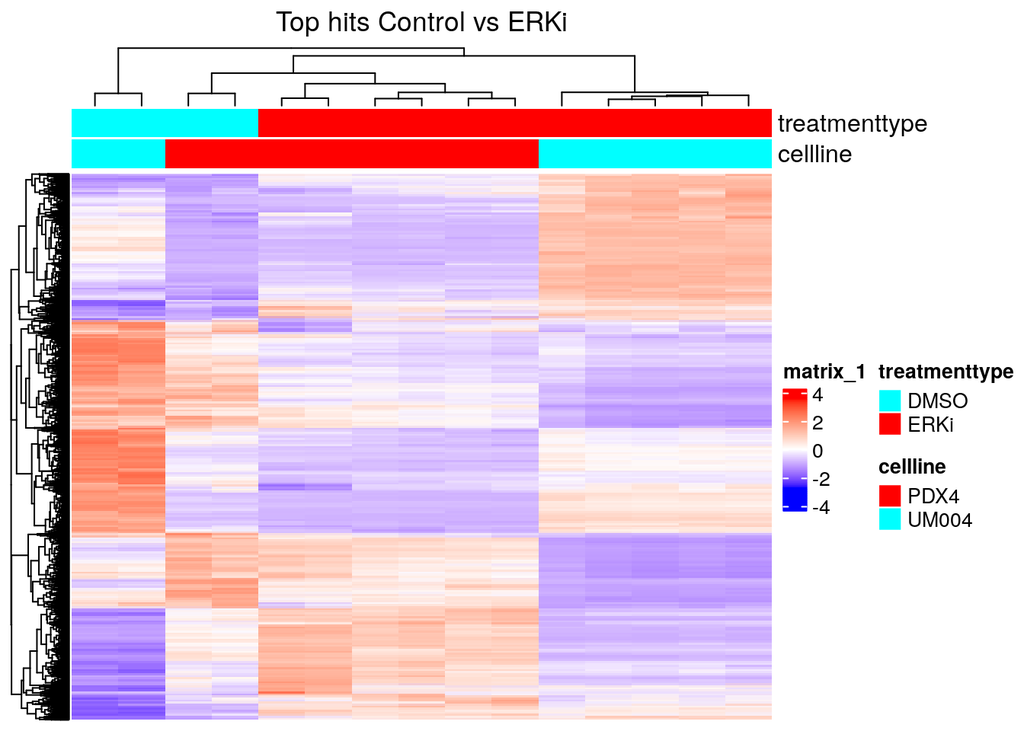

**Figure 7:** Heatmap of differentially expressed genes for ERKi vs control

```r
heatmap_matrix_ERKi <- t(scale(t(normalised_counts_ERKi)))
top_hits_ERKi <- rownames(qlf_output_hits_ERKi$table)[qlf_output_hits_ERKi$table$PValue<0.05]
heatmap_matrix_tophits_ERKi <- t(scale(t(heatmap_matrix_ERKi[which(rownames(heatmap_matrix_ERKi) %in% top_hits_ERKi),])))
# generating colour gradient based on number
if(min(heatmap_matrix_tophits_ERKi) == 0){
heatmap_col = colorRamp2(c( 0, max(heatmap_matrix_tophits_ERKi)), c( "white", "red"))
} else { # blue for negative
heatmap_col = colorRamp2(c(min(heatmap_matrix_tophits_ERKi), 0,
max(heatmap_matrix_tophits_ERKi)), c("blue", "white", "red"))
}
# creating unique labels for treatment type and cell line
unique_treatmenttype <- unique(ERKi_and_DMSO$treatment.type)
unique_treatmenttypecolors <- rainbow(n = length(unique_treatmenttype))
names(unique_treatmenttypecolors) <- unique_treatmenttype
unique_cellline <- unique(ERKi_and_DMSO$cell.line)
unique_celllinecolors <- rainbow(n = length(unique_cellline))
names(unique_celllinecolors) <- unique_cellline

# creating annotation labels for treatment type and cell line
ha_pat <- HeatmapAnnotation(df = data.frame(
treatmenttype = ERKi_and_DMSO$treatment.type,
cellline = ERKi_and_DMSO$cell.line ),
col = list(
treatmenttype = unique_treatmenttypecolors,
cellline = unique_celllinecolors),
show_legend = TRUE)

#generation of heatmap
top_heatmap_ERKi <- Heatmap(as.matrix(heatmap_matrix_tophits_ERKi),
  top_annotation = ha_pat,
  cluster_rows = TRUE, cluster_columns = TRUE,
  show_row_dend = TRUE, show_column_dend = TRUE,
  col=heatmap_col, show_column_names = FALSE,
  show_row_names = FALSE, show_heatmap_legend = TRUE, use_raster=TRUE,
  column_title =("Top hits Control vs ERKi")
)
top_heatmap_ERKi
```

This process is repeated for MEKi.

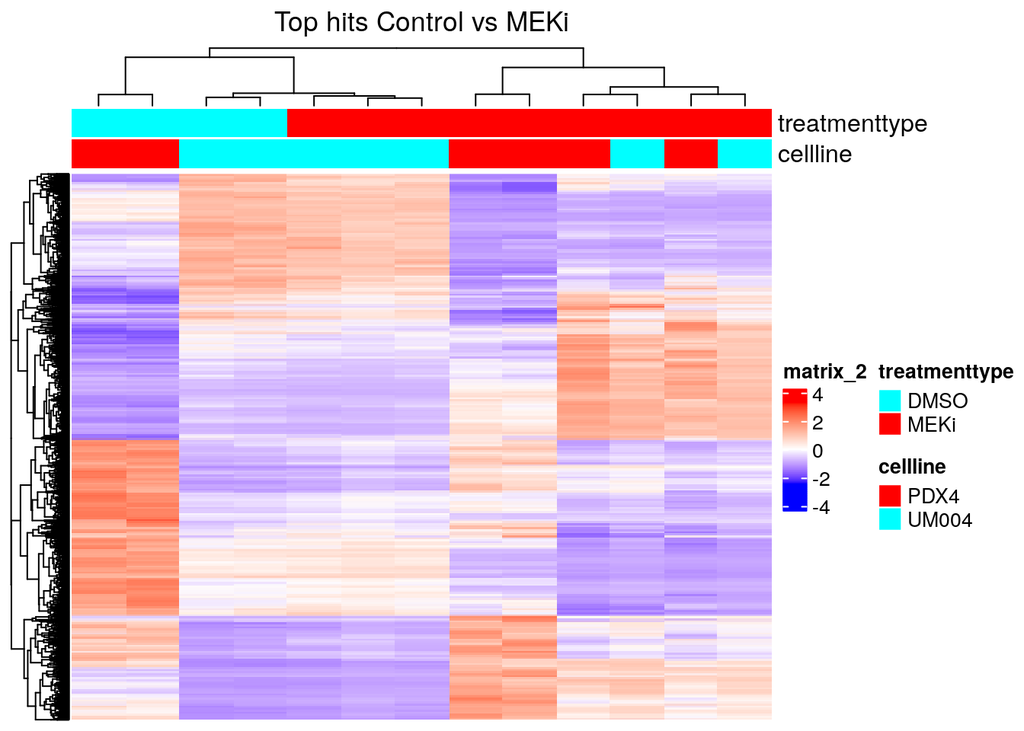

**Figure 8:** Heatmap of differentially expressed genes for MEKi vs control

```r
heatmap_matrix_MEKi <- t(scale(t(normalised_counts_MEKi)))
top_hits_MEKi <- rownames(qlf_output_hits_MEKi$table)[qlf_output_hits_MEKi$table$PValue<0.05]
heatmap_matrix_tophits_MEKi <- t(scale(t(heatmap_matrix_MEKi[which(rownames(heatmap_matrix_MEKi) %in% top_hits_MEKi),])))
# generating colour gradient based on number
if(min(heatmap_matrix_tophits_MEKi) == 0){
heatmap_col = colorRamp2(c( 0, max(heatmap_matrix_tophits_MEKi)), c( "white", "red"))
} else { # blue for negative
heatmap_col = colorRamp2(c(min(heatmap_matrix_tophits_MEKi), 0,
max(heatmap_matrix_tophits_MEKi)), c("blue", "white", "red"))
}
# creating unique labels for treatment type and cell line
unique_treatmenttype <- unique(MEKi_and_DMSO$treatment.type)
unique_treatmenttypecolors <- rainbow(n = length(unique_treatmenttype))
names(unique_treatmenttypecolors) <- unique_treatmenttype
unique_cellline <- unique(MEKi_and_DMSO$cell.line)
unique_celllinecolors <- rainbow(n = length(unique_cellline))
names(unique_celllinecolors) <- unique_cellline
# sort by treatment type
heatmap_matrix_tophits_MEKi <- heatmap_matrix_tophits_MEKi[, order(MEKi_and_DMSO$treatment.type)]
# creating annotation labels for treatment type and cell line
ha_pat <- HeatmapAnnotation(df = data.frame(
treatmenttype = MEKi_and_DMSO$treatment.type,
cellline = MEKi_and_DMSO$cell.line ),
col = list(
treatmenttype = unique_treatmenttypecolors,
cellline = unique_celllinecolors),
show_legend = TRUE)

#generation of heatmap
top_heatmap_MEKi <- Heatmap(as.matrix(heatmap_matrix_tophits_MEKi),
  top_annotation = ha_pat,
  cluster_rows = TRUE, cluster_columns = TRUE,
  show_row_dend = TRUE, show_column_dend = TRUE,
  col=heatmap_col, show_column_names = FALSE,
  show_row_names = FALSE, show_heatmap_legend = TRUE, use_raster=TRUE,
  column_title =("Top hits Control vs MEKi")
)
top_heatmap_MEKi
```

It can be seen that the clustering is more dependent on cell type than treatment type, which makes sense as different cell lines have different basal gene expression levels, and should see different genes being expressed between different cell types. This agrees with the MDS plot earlier, as a large majority of differences lie due to the differences in cell line, with a MDS vector explaining almost 90% of the differences between different cell lines.

## Thresholded over-representation analysis

```r
ERKi_upregulated <- qlf.treatment_typeERKi$table[qlf.treatment_typeERKi$table$PValue < 0.05 & qlf.treatment_typeERKi$table$logFC > 0, ]
ERKi_downregulated <- qlf.treatment_typeERKi$table[qlf.treatment_typeERKi$table$PValue < 0.05 & qlf.treatment_typeERKi$table$logFC < 0, ]
MEKi_upregulated <- qlf.treatment_typeMEKi$table[qlf.treatment_typeMEKi$table$PValue < 0.05 & qlf.treatment_typeMEKi$table$logFC > 0, ]
MEKi_downregulated <- qlf.treatment_typeMEKi$table[qlf.treatment_typeMEKi$table$PValue < 0.05 & qlf.treatment_typeMEKi$table$logFC < 0, ]
```

After creating the thresholded list of genes, I then save these genes for easier subsequent pathway analysis.

```r
dir.create("gprofiler")
write.table(x=rownames(qlf.treatment_typeERKi$table), file=file.path(getwd(),"gprofiler","ERKi_allgenes.txt"), sep = "\t",row.names = FALSE, col.names = FALSE,quote = FALSE)
write.table(x=rownames(qlf.treatment_typeMEKi$table), file=file.path(getwd(),"gprofiler","MEKi_allgenes.txt"), sep = "\t",row.names = FALSE, col.names = FALSE,quote = FALSE)
write.table(x=rownames(ERKi_upregulated), file=file.path(getwd(),"gprofiler","ERKi_upregulated.txt"), sep = "\t",row.names = FALSE, col.names = FALSE,quote = FALSE)
write.table(x=rownames(ERKi_downregulated), file=file.path(getwd(),"gprofiler","ERKi_downregulated.txt"), sep = "\t",row.names = FALSE, col.names = FALSE,quote = FALSE)
write.table(x=rownames(MEKi_upregulated), file=file.path(getwd(),"gprofiler","MEKi_upregulated.txt"), sep = "\t",row.names = FALSE, col.names = FALSE,quote = FALSE)
write.table(x=rownames(MEKi_downregulated), file=file.path(getwd(),"gprofiler","MEKi_downregulated.txt"), sep = "\t",row.names = FALSE, col.names = FALSE,quote = FALSE)
```

```r
suppressMessages(library(gprofiler2))
#where to put all the generated files
working_dir <- file.path(getwd(), "gprofiler")

# where to find the data files needed to run the analysis
data_dir <-  file.path(getwd(), "gprofiler")

# default max size of the genesets
max_gs_size <- 500

# default min size of the genesets
min_gs_size <- 10

#min intersection between your genelist and the geneset
min_intersection <- 10

# organism parameter used for g:profiler.
organism <- "hsapiens"

# the below script will automatically download the latest gmt file from
# baderlab webstie.
dest_gmt_file = ""

getQuerySet <- function(genelist_file) {
  # takes in the file name containing the list of genes to be used for analysis
  #load in the file
  current_genelist <- read.table(file = file.path(data_dir, genelist_file),
                               header = FALSE, sep = "\t", quote = "",
                               stringsAsFactors = FALSE)
  return (current_genelist$V1)
}
```

```r
gprofiler_results <- gost(query = getQuerySet("ERKi_allgenes.txt") ,
                          significant=FALSE,
                          ordered_query = FALSE,
                          exclude_iea=TRUE,
                          correction_method = "fdr",
                          organism = organism,
                          source = c("REAC","WP","GO:BP"))
 #get the gprofiler results table
enrichment_results <- gprofiler_results$result

dim(enrichment_results)
```

```
## [1] 16069    14
```

I repeat this for all gene lists. This shows that running the analysis on all upregulated and downregulated genes separately gives different results than when running together.

```r
analyzeGenelistFile <- function(genelist_file) {
  query_set <- getQuerySet(genelist_file)
  gprofiler_results <- gost(query = query_set,
                            significant = FALSE,
                            ordered_query = FALSE,
                            exclude_iea = TRUE,
                            correction_method = "fdr",
                            organism = organism,
                            source = c("REAC", "WP", "GO:BP"))

  print(paste(genelist_file, dim(gprofiler_results$result)))
  return(gprofiler_results$result)
}

txt_files <- list.files(path = "gprofiler", pattern = "\\.txt$")

# Iterate through each file
for (genelist_file in txt_files) {
  variable_name <- paste0(genelist_file, "_genesets")
  assign(variable_name, analyzeGenelistFile(genelist_file))
}
```

```
## [1] "ERKi_allgenes.txt 16069" "ERKi_allgenes.txt 14"
## [1] "ERKi_downregulated.txt 11017" "ERKi_downregulated.txt 14"
## [1] "ERKi_upregulated.txt 10883" "ERKi_upregulated.txt 14"
## [1] "MEKi_allgenes.txt 16069" "MEKi_allgenes.txt 14"
## [1] "MEKi_downregulated.txt 11209" "MEKi_downregulated.txt 14"
## [1] "MEKi_upregulated.txt 11229" "MEKi_upregulated.txt 14"
```

Of all the genesets, these are the genesets that have p value < 0.05. These are different when calculating for downregulated and upregulated separately. I also find the number of genesets containing the term ‘kinase’.

```r
genelist_file <- ERKi_allgenes.txt_genesets
print(dim(genelist_file[genelist_file[3] < 0.05, ]))
```

```
## [1] 2081   14
```

```r
print(dim(genelist_file[grep("kinase", genelist_file[, 11], ignore.case = TRUE), ]))
```

```
## [1] 113  14
```

```r
#knitr::kable(head(genelist_file))
genelist_file <- ERKi_downregulated.txt_genesets
print(dim(genelist_file[genelist_file[3] < 0.05, ]))
```

```
## [1] 1385   14
```

```r
print(dim(genelist_file[grep("kinase", genelist_file[, 11], ignore.case = TRUE), ]))
```

```
## [1] 83 14
```

```r
#knitr::kable(head(genelist_file))
genelist_file <- ERKi_upregulated.txt_genesets
print(dim(genelist_file[genelist_file[3] < 0.05, ]))
```

```
## [1] 565  14
```

```r
print(dim(genelist_file[grep("kinase", genelist_file[, 11], ignore.case = TRUE), ]))
```

```
## [1] 81 14
```

```r
#knitr::kable(head(genelist_file))
genelist_file <- MEKi_allgenes.txt_genesets
print(dim(genelist_file[genelist_file[3] < 0.05, ]))
```

```
## [1] 2081   14
```

```r
print(dim(genelist_file[grep("kinase", genelist_file[, 11], ignore.case = TRUE), ]))
```

```
## [1] 113  14
```

```r
#knitr::kable(head(genelist_file))
genelist_file <- MEKi_downregulated.txt_genesets
print(dim(genelist_file[genelist_file[3] < 0.05, ]))
```

```
## [1] 1473   14
```

```r
print(dim(genelist_file[grep("kinase", genelist_file[, 11], ignore.case = TRUE), ]))
```

```
## [1] 85 14
```

```r
#knitr::kable(head(genelist_file))
genelist_file <- MEKi_upregulated.txt_genesets
print(dim(genelist_file[genelist_file[3] < 0.05, ]))
```

```
## [1] 590  14
```

```r
print(dim(genelist_file[grep("kinase", genelist_file[, 11], ignore.case = TRUE), ]))
```

```
## [1] 84 14
```

```r
#knitr::kable(head(genelist_file))
```

Note that a specific version of gmt file is used, which is e111_eg58_p18_30541362, and I save this gmt file for future use.

```r
#the link to the gmt file is static no matter what version
gprofiler_gmt_url <-
  "https://biit.cs.ut.ee/gprofiler/static/gprofiler_full_hsapiens.name.gmt"

#get version info gprofiler as the gmt file is always associated with
# a specific version of g:profiler
gprofiler_version <- get_version_info(organism=organism)

gprofiler_gmt_filename <- file.path(working_dir,
                                  paste("gprofiler_full", organism,
                                    gprofiler_version$gprofiler_version,sep="_",
                                    ".name.gmt"))

if(!file.exists(gprofiler_gmt_filename)){
  download.file(url = gprofiler_gmt_url,
              destfile = gprofiler_gmt_filename)
}

#load in the g:profiler geneset file
suppressMessages(library(GSA))
capt_output <- capture.output(genesets_gprofiler <- GSA.read.gmt(
                                      filename = gprofiler_gmt_filename))

names(genesets_gprofiler$genesets) <- genesets_gprofiler$geneset.names

#preserve the database version so revisiting these results in future
#leads to same results. done by creating symbolic link
if(length(grep(x = list.files(file.path(working_dir)),
              pattern = "gprofiler_full_hsapiens.name.gmt",
              fixed = TRUE) > 0 )){
  file.remove(file.path(working_dir, "gprofiler_full_hsapiens.name.gmt"))
}
```

```
## [1] TRUE
```

```r
file.symlink( gprofiler_gmt_filename,file.path(working_dir,
                                   "gprofiler_full_hsapiens.name.gmt"))
```

```
## [1] TRUE
```

## Interpretation

I can find evidence, i.e. publications, to support some of the results that I see. The research papers (Essegian et al. 2020), (Kurimchak et al. 2020) and (Baqai et al. 2023) all go to show that kinase activity is important and relevant in cancer treatments.

## References

Baqai, Usman, Alison M. Kurimchak, Isabella V. Trachtenberg, Timothy J. Purwin, Jelan I. Haj, Anna Han, Kristine Luo, et al. 2023. “Kinome Profiling Identifies MARK3 and STK10 as Potential Therapeutic Targets in Uveal Melanoma.” *The Journal of Biological Chemistry* 299 (12): 105418. https://doi.org/10.1016/j.jbc.2023.105418.

Essegian, Derek, Rimpi Khurana, Vasileios Stathias, and Stephan C. Schürer. 2020. “The Clinical Kinase Index: A Method to Prioritize Understudied Kinases as Drug Targets for the Treatment of Cancer.” *Cell Reports. Medicine* 1 (7): 100128. https://doi.org/10.1016/j.xcrm.2020.100128.

Kurimchak, Alison M., Carlos Herrera-Montávez, Jennifer Brown, Katherine J. Johnson, Valerie Sodi, Nishi Srivastava, Vikas Kumar, et al. 2020. “Functional Proteomics Interrogation of the Kinome Identifies MRCKA as a Therapeutic Target in High-Grade Serous Ovarian Carcinoma.” *Science Signaling* 13 (619): eaax8238. https://doi.org/10.1126/scisignal.aax8238.